# Working with GEDI data

J Camilo Fagua and Patrick Jantz

June 2021

## **1. INTRODUCTION**

The NASA Global Ecosystem Dynamics Investigation (GEDI) is a spaceborne lidar instrument operating onboard the International Space Station (ISS) that is collecting data since April 2019 (Dubayah et al. 2020). GEDI is a waveform lidar designed for measuring vegetation structure and consist of footprint-based measurements collected between ~51.6N and ~51.6 S globally. Data coverage is limited by the ISS orbit inclination (Figure 1); this video shows why GEDI orbit footprint looks like figure 1 [here.](https://www.youtube.com/watch?v=2Es54D7h2H0)

[figure not shown]

**Figure 1**. GEDI orbit footprint.

It is expected that GEDI samples 4% of the Earth’s land surface over a nominal two year mission (Potapov et al. 2020). Main objectives of the GEDI mission includes the improvement of aboveground biomass estimation of tropical and temperate forests, modeling land surface carbon budgets, and understanding the effects of vegetation structure on biodiversity.

NASA has generated products to facility the use of GEDI data to users. These data products are assigned different levels, which indicate the amount of processing that the data has undergone after collection. All products are publicly available, with the lower-level products (L1 & L2) from NASA’s Land Processes Distributed Active Archive Center (LPDAAC) and the higher level (L3 & L4) from the ORNL DAAC (TABLE 1). GEDI data products have limitations for practical applications because their footprints represent point samples of a limited portion of the land area. Consequently, their integration with multispectral and SAR data time-series enables the spatiotemporal extrapolation of GEDI information for consistent multidecadal monitoring of vegetation structure. Even after GEDI integration with multispectral and SAR, sampling may not be suitable for targeting rare forest change events.

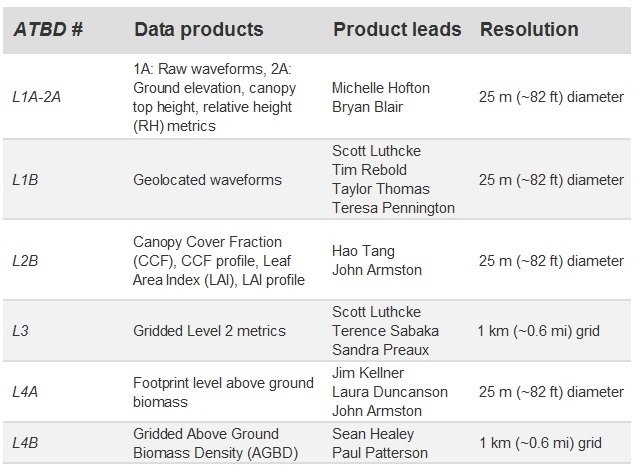

**TABLE 1**. GEDI products.

We also need other five R libraries in this tutorial:

1. rgdal: It provides access to the ‘Geospatial’ Data Abstraction Library-GDAL.
2. raster: A large compilation of functions to read, write, manipulate, analyze, and model spatial data.
3. ggplot2: A visualization package.
4. RStoolbox: To read raster in ggplot.
5. rhdf5: To read .h5 files.

Let us go to start. If you do not have these libraries in the R, installed them before running the command library:

```r
#install.packages("rGEDI")
#install.packages("rgdal")
#install.packages("raster")
#install.packages("ggplot2")
#install.packages("RStoolbox")
#install.packages("rhdf5")
library(rGEDI)
library(rgdal)
library(raster)
library(ggplot2)
library(RStoolbox)
library(rhdf5)
```

Now, adjust memory and set directory.

```r
#setwd("")
rm(list = ls())# To clean memory
gc()# to prompt R to return memory
```

```
##           used  (Mb) gc trigger  (Mb) max used  (Mb)
## Ncells 3458648 184.8    5118512 273.4  5118512 273.4
## Vcells 5157513  39.4   10146329  77.5  8388083  64.0
```

```r
setwd("C:/COURSE_SPATIAL_ANALYSIS_UNAL/GEDI_LIDAR/tutorial")
```

To see study area in red, we are going to open some .shp files.

```r
COLOMBIA <- readOGR(dsn = ".", layer = "COLOMBIA")
AMAZONAS <- readOGR(dsn = ".", layer = "Lim_Amazonia")
```

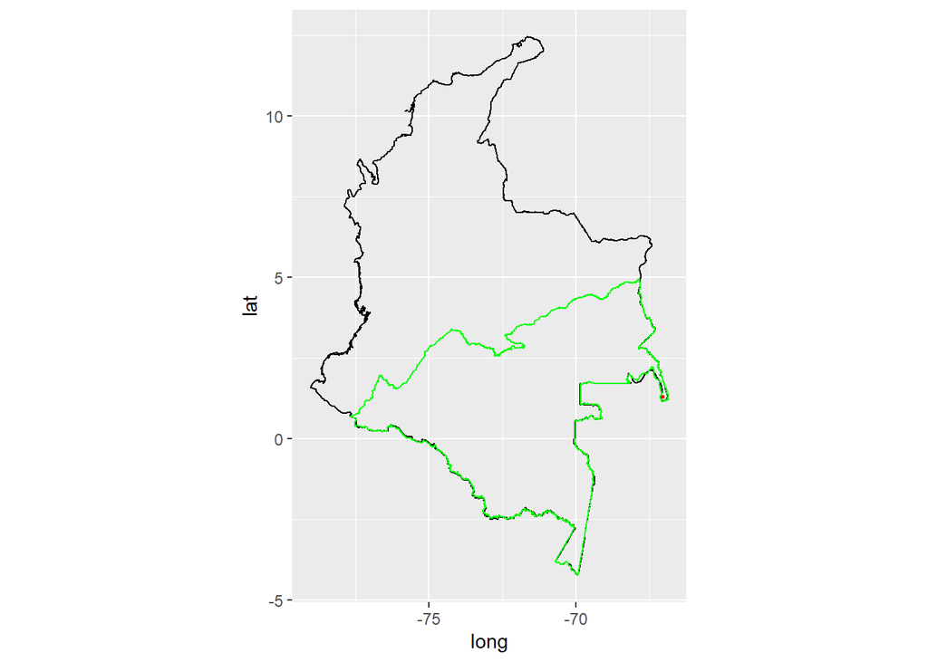

```r
STUDY_AREA <- readOGR(dsn = ".", layer = "PLOT")
world <- map_data("world")

ggplot() +
  geom_polygon(data = COLOMBIA, aes(x=long, y = lat, group = group), fill = NA, color = "black")+coord_fixed(1.1)+
  geom_polygon(data = AMAZONAS, aes(x=long, y = lat, group = group), fill = NA, color = "green")+
  geom_polygon(data = STUDY_AREA, aes(x=long, y = lat, group = group), fill = NA, color = "red")
```

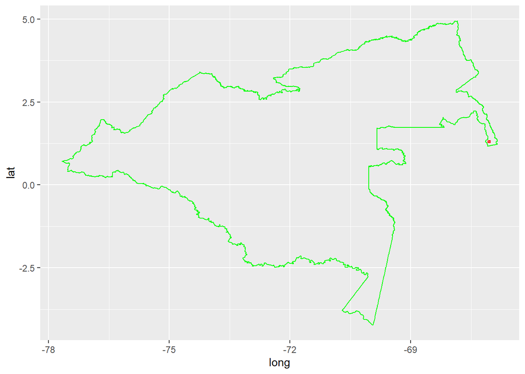

```r
ggplot() +
  geom_polygon(data = AMAZONAS, aes(x=long, y = lat, group = group), fill = NA, color = "green")+
  geom_polygon(data = STUDY_AREA, aes(x=long, y = lat, group = group), fill = NA, color = "red")
```

## **2. PROCESSING GEDI DATA**

Now we are going to generate the list of GEDI data for the study area. First, we select coordinates using the limits of the study area.

```r
STUDY_AREA
```

```
## class       : SpatialPolygonsDataFrame
## features    : 2
## extent      : -67.08159, -67.01984, 1.268833, 1.326955  (xmin, xmax, ymin, ymax)
## crs         : +proj=longlat +datum=WGS84 +no_defs
## variables   : 1
## names       : Id
## min values  :  0
## max values  :  0
```

```r
ul_lat<- 1.326955 #ymax
ul_lon<- -67.08159 #xmax
lr_lat<- 1.268833 # ymin,
lr_lon<- -67.01984 #xmax
```

We then define the dates to obtain the GEDI data. By using the function gedifinder, we also can get the paths of the GEDI data corresponding to a study area between specific dates.

```r
daterange=c("2019-01-01","2019-12-31")

gLevel1B<-gedifinder(product="GEDI01_B",ul_lat, ul_lon, lr_lat, lr_lon,version="001",daterange=daterange)
gLevel1B
```

```
## [1] "https://e4ftl01.cr.usgs.gov/GEDI/GEDI01_B.001/2019.11.08/GEDI01_B_2019312122729_O05133_T03693_02_003_01.h5"
## [2] "https://e4ftl01.cr.usgs.gov/GEDI/GEDI01_B.001/2019.10.16/GEDI01_B_2019289212437_O04782_T02423_02_003_01.h5"
## [3] "https://e4ftl01.cr.usgs.gov/GEDI/GEDI01_B.001/2019.04.20/GEDI01_B_2019110092939_O01996_T03334_02_003_01.h5"
```

```r
gLevel2A<-gedifinder(product="GEDI02_A",ul_lat, ul_lon, lr_lat, lr_lon,version="001",daterange=daterange)
gLevel2A
```

```
## [1] "https://e4ftl01.cr.usgs.gov/GEDI/GEDI02_A.001/2019.11.08/GEDI02_A_2019312122729_O05133_T03693_02_001_01.h5"
## [2] "https://e4ftl01.cr.usgs.gov/GEDI/GEDI02_A.001/2019.10.16/GEDI02_A_2019289212437_O04782_T02423_02_001_01.h5"
## [3] "https://e4ftl01.cr.usgs.gov/GEDI/GEDI02_A.001/2019.04.20/GEDI02_A_2019110092939_O01996_T03334_02_001_01.h5"
```

```r
gLevel2B<-gedifinder(product="GEDI02_B",ul_lat, ul_lon, lr_lat, lr_lon,version="001",daterange=daterange)
gLevel2B
```

```
## [1] "https://e4ftl01.cr.usgs.gov/GEDI/GEDI02_B.001/2019.11.08/GEDI02_B_2019312122729_O05133_T03693_02_001_01.h5"
## [2] "https://e4ftl01.cr.usgs.gov/GEDI/GEDI02_B.001/2019.10.16/GEDI02_B_2019289212437_O04782_T02423_02_001_01.h5"
## [3] "https://e4ftl01.cr.usgs.gov/GEDI/GEDI02_B.001/2019.04.20/GEDI02_B_2019110092939_O01996_T03334_02_001_01.h5"
```

You need to register at EARTHDATA [here](https://urs.earthdata.nasa.gov/) to download GEDI data. EARTHDAT is an application to access more than 33,000 earth observation data collections from NASA’s EOSDIS and other international partner agencies (Figure 2).

[figure not shown]

**Figure 2**. EARTHDATA registration website.

Now that you are registered at EARTHDATA, you will need to provide your username and password to download GEDI data after running the function gediDownload(). You can find these GEDI data in the folder of this tutorial, so you do not need to download. We prefer to avoid the data downloading because it takes long time and the EARTHDATA server sometimes presents connection issues. But you can use these lines of code to download GEDI data for any site and dates of your interest.

```r
#outdir=getwd()#To return the filepath of your current working directory
#gediDownload(filepath=gLevel1B,outdir=outdir)
#gediDownload(filepath=gLevel2A,outdir=outdir)
#gediDownload(filepath=gLevel2B,outdir=outdir)
```

Now, we are going to read the GEDI L1B (Geolocated waveforms product) for our study area in the amazon forest of the Vaupes Department (Colombia) for 2019.

```r
outdir=getwd()# To fit the working directory
gedilevel1b_1 = readLevel1B(level1Bpath = paste0(outdir,"/GEDI01_B_2019312122729_O05133_T03693_02_003_01.h5"))
```

You can evaluate the R class and structure of this data.

```r
class(gedilevel1b_1)
```

```
## [1] "gedi.level1b"
## attr(,"package")
## [1] "rGEDI"
```

```r
#str(gedilevel1b_1)
```

We now are going to reduce the data by selecting 1000 footprints randomly. Then, we generate a map to observe the distribution of the data. This map shows the classical GEDI orbit.

[output not shown]

[output not shown]

[output not shown]

[figure not shown]

You can convert level1bGeo_1 data as data.frame or SpatialPointsDataFrame. Under these formats, the GEDI data can be operated using the large sets of other R libraries. .

```r
level1bGeo_1_sp<-SpatialPointsDataFrame(cbind(level1bGeo_1$longitude_bin0, level1bGeo_1$latitude_bin0),
                                        data=level1bGeo_1)
```

For instance, we can export the SpatialPointsDataFrame in a ESRI shapefile. We are not going to export the data due to the time execution. Remember that you first need to Converting shot_number as “integer64” to “character” to export as a ESRI shapefile.

```r
#level1bGeo_1_sp$shot_number<-paste0(level1bGeo_1_sp$shot_number)
#raster::shapefile(level1bGeo_1_sp, paste0(outdir,"\\GEDI01_B_SHP"))
```

Our current level1bGeo_1 data is the whole data of an orbit that touch our study area at Vaupes. We can clip and map the footprints of the study area.

```r
level1bGeo_1_sp_clip = crop(x=level1bGeo_1_sp, y=STUDY_AREA)
dim(level1bGeo_1_sp)
```

```
## [1] 3103134       6
```

```r
dim(level1bGeo_1_sp_clip)
```

```
## [1] 606   6
```

```r
class(level1bGeo_1_sp_clip)
```

```
## [1] "SpatialPointsDataFrame"
## attr(,"package")
## [1] "sp"
```

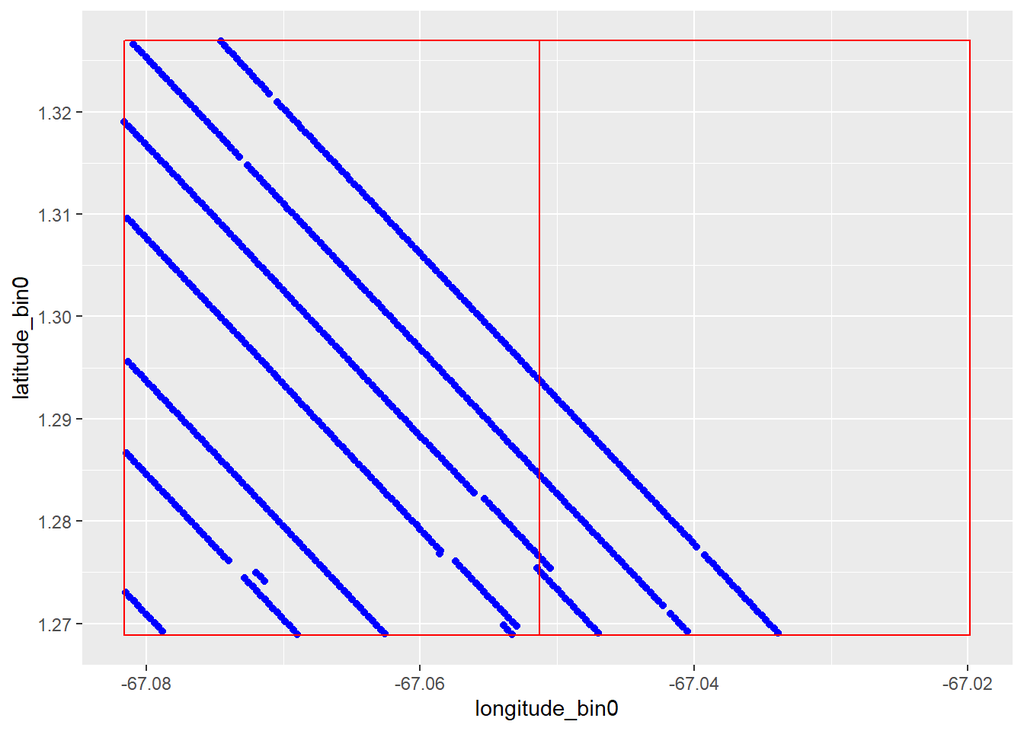

```r
level1bGeo_1_sp_clip= as.data.frame(level1bGeo_1_sp_clip)

ggplot() +
  geom_point(data = level1bGeo_1_sp_clip, aes(x=longitude_bin0, y = latitude_bin0), fill = NA, color = "blue")+
  geom_polygon(data = STUDY_AREA, aes(x=long, y = lat, group = group), fill = NA, color = "red")
```

Also you can export this data.frame

```r
class(level1bGeo_1_sp_clip)
```

```
## [1] "data.frame"
```

```r
write.csv(level1bGeo_1_sp_clip, "level1bGeo_1_sp_clip.csv", row.names = T)
```

With some small variations, you can repeat the previous process for GEDI L2A. We put the whole code chunks together. Again, we are not going to export the data as ESRI shape file due to the time execution. However, the codes are provided but are not activate in the code.

```r
outdir=getwd()
gedilevel2a_1 = readLevel2A(level2Apath = paste0(outdir,"/GEDI02_A_2019110092939_O01996_T03334_02_001_01.h5"))
class(gedilevel2a_1)
```

```
## [1] "gedi.level2a"
## attr(,"package")
## [1] "rGEDI"
```

```r
level2a_1<-getLevel2AM(gedilevel2a_1)
head(level2a_1)
```

```
##        beam       shot_number degrade_flag quality_flag delta_time sensitivity
## 1: BEAM0000 19960018200000001            0            0   40988609  1.70097005
## 2: BEAM0000 19960018300000002            0            0   40988609  0.36081040
## 3: BEAM0000 19960018400000003            0            0   40988609 -0.01893344
## 4: BEAM0000 19960018500000004            0            0   40988609  2.67865634
## 5: BEAM0000 19960018600000005            0            0   40988609 -5.53235245
## 6: BEAM0000 19960018700000006            0            0   40988609 -0.25693703
##    solar_elevation lat_lowestmode lon_lowestmode elev_highestreturn
## 1:       -34.86621      -26.93154      -89.26087           8680.280
## 2:       -34.86604      -26.93135      -89.26068           8680.214
## 3:       -34.86588      -26.93116      -89.26049           8680.747
## 4:       -34.86570      -26.93097      -89.26030           8680.681
## 5:       -34.86554      -26.93077      -89.26011           8681.214
## 6:       -34.86536      -26.93058      -89.25992           8680.549
##    elev_lowestmode rh0 rh1 rh2 rh3 rh4 rh5 rh6 rh7 rh8 rh9 rh10 rh11 rh12 rh13
```

[output cut: 48 more lines]

```r
dim(level2a_1)
```

```
## [1] 3991600     112
```

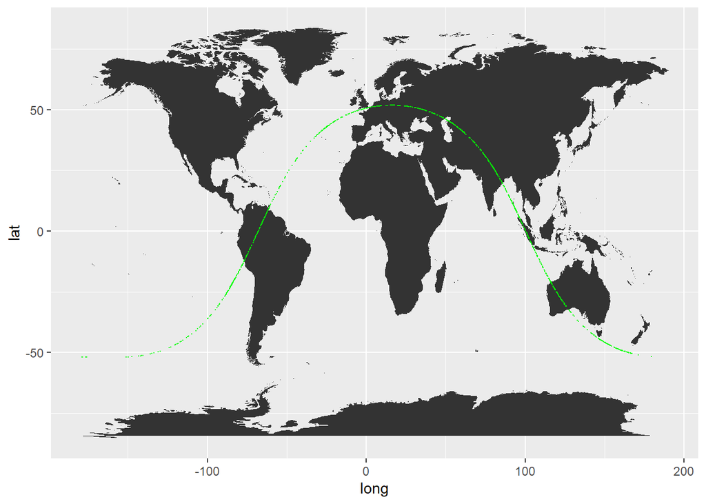

```r
level2aGeo_1_set1000 = level2a_1[sample(nrow(level2a_1), 1000), ]

ggplot() +geom_map(data = world, map = world,aes(long, lat, map_id = region))+
  geom_point(data = level2aGeo_1_set1000, mapping = aes(x = lon_lowestmode, y = lat_lowestmode),size =0.001,color = "green")
```

```r
level2aGeo_1_sp<-SpatialPointsDataFrame(cbind(level2a_1$lon_lowestmode, level2a_1$lat_lowestmode),
                                        data=level2a_1)

#level2aGeo_1_sp$shot_number<-paste0(level2aGeo_1_sp$shot_number)
#raster::shapefile(level2aGeo_1_sp, paste0(outdir,"\\GEDI02_A_SHP"))

level2aGeo_1_sp_clip = crop(x=level2aGeo_1_sp, y=STUDY_AREA)
dim(level2aGeo_1_sp_clip)
```

```
## [1] 948 112
```

```r
dim(level2aGeo_1_sp_clip)
```

```
## [1] 948 112
```

```r
class(level2aGeo_1_sp_clip)
```

```
## [1] "SpatialPointsDataFrame"
## attr(,"package")
## [1] "sp"
```

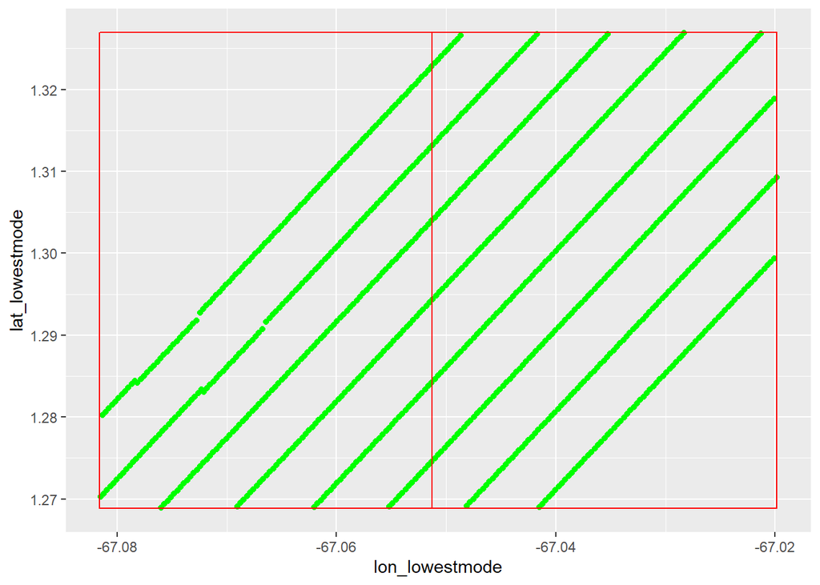

```r
level2aGeo_1_sp_clip= as.data.frame(level2aGeo_1_sp_clip)

ggplot() +
  geom_point(data = level2aGeo_1_sp_clip, aes(x=lon_lowestmode, y = lat_lowestmode), fill = NA, color = "green")+
  geom_polygon(data = STUDY_AREA, aes(x=long, y = lat, group = group), fill = NA, color = "red")
```

```r
class(level2aGeo_1_sp_clip)
```

```
## [1] "data.frame"
```

```r
write.csv(level2aGeo_1_sp_clip, "level2aGeo_1_sp_clip.csv", row.names = T)
```

As well, you can repeat the previous process for GEDI L2B with some small variations. We also added the whole code chunks together. We are not going to export the data as ESRI shape file due to the time execution (codes are provided but not activate).

```r
gedilevel2b_1 = readLevel2B(level2Bpath = paste0(outdir,"/GEDI02_B_2019312122729_O05133_T03693_02_001_01.h5"))
class(gedilevel2b_1)
```

```
## [1] "gedi.level2b"
## attr(,"package")
## [1] "rGEDI"
```

```r
level2BVPM_1<-getLevel2BVPM(gedilevel2b_1)
head(level2BVPM_1)
```

```
##        beam       shot_number algorithmrun_flag l2b_quality_flag delta_time
## 1: BEAM0000 51330006600000001                 0                0   58452150
## 2: BEAM0000 51330006700000002                 0                0   58452150
## 3: BEAM0000 51330006800000003                 0                0   58452150
## 4: BEAM0000 51330006900000004                 0                0   58452150
## 5: BEAM0000 51330007000000005                 0                0   58452150
## 6: BEAM0000 51330007100000006                 0                0   58452150
##    sensitivity solar_elevation latitude_lastbin latitude_bin0 longitude_bin0
## 1:  -0.7707085       -20.39968        -23.60354     -23.60354       107.4299
## 2: -23.2872887       -20.39994        -23.60334     -23.60334       107.4301
## 3:  -0.8289917       -20.40019        -23.60314     -23.60314       107.4303
## 4:  84.7844620       -20.40045        -23.60295     -23.60295       107.4304
## 5:   9.1504021       -20.40070        -23.60275     -23.60275       107.4306
## 6:  10.7115097       -20.40096        -23.60255     -23.60255       107.4308
##    longitude_lastbin elev_highestreturn elev_lowestmode rh100   pai fhd_normal
## 1:          107.4299          -170.9061       -170.9061     0 -9999      -9999
## 2:          107.4301          -171.5551       -171.5551     0 -9999      -9999
## 3:          107.4303          -171.0054       -171.0054     0 -9999      -9999
## 4:          107.4304          -171.0550       -171.0550     0 -9999      -9999
## 5:          107.4306          -171.1046       -171.1046     0 -9999      -9999
## 6:          107.4308          -171.7536       -171.7536     0 -9999      -9999
##    omega pgap_theta cover
## 1:     1      -9999 -9999
## 2:     1      -9999 -9999
## 3:     1      -9999 -9999
## 4:     1      -9999 -9999
## 5:     1      -9999 -9999
## 6:     1      -9999 -9999
```

```r
dim(level2BVPM_1)
```

```
## [1] 3103134      19
```

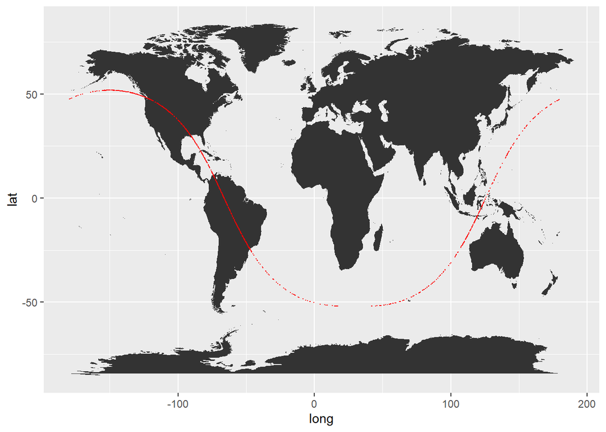

```r
level2BVPM_1_set1000 = level2BVPM_1[sample(nrow(level2BVPM_1), 1000), ]

ggplot() +geom_map(data = world, map = world,aes(long, lat, map_id = region))+
  geom_point(data = level2BVPM_1_set1000, mapping = aes(x = longitude_bin0, y = latitude_bin0),size =0.001,color = "red")
```

```r
level2BVPM_Geo_1_sp<-SpatialPointsDataFrame(cbind(level2BVPM_1$longitude_bin0, level2BVPM_1$latitude_bin0),
                                        data=level2BVPM_1)


#level2BVPM_Geo_1_sp$shot_number<-paste0(level2BVPM_Geo_1_sp$shot_number)
#raster::shapefile(level2BVPM_Geo_1_sp, paste0(outdir,"\\GEDI02_B_2019312122729_O05133_T03693_02_001_01_sub"))

level2BVPM_Geo_1_sp_clip = crop(x=level2BVPM_Geo_1_sp, y=STUDY_AREA)
dim(level2BVPM_Geo_1_sp_clip)
```

```
## [1] 606  19
```

```r
dim(level2BVPM_Geo_1_sp_clip)
```

```
## [1] 606  19
```

```r
class(level2BVPM_Geo_1_sp_clip)
```

```
## [1] "SpatialPointsDataFrame"
## attr(,"package")
## [1] "sp"
```

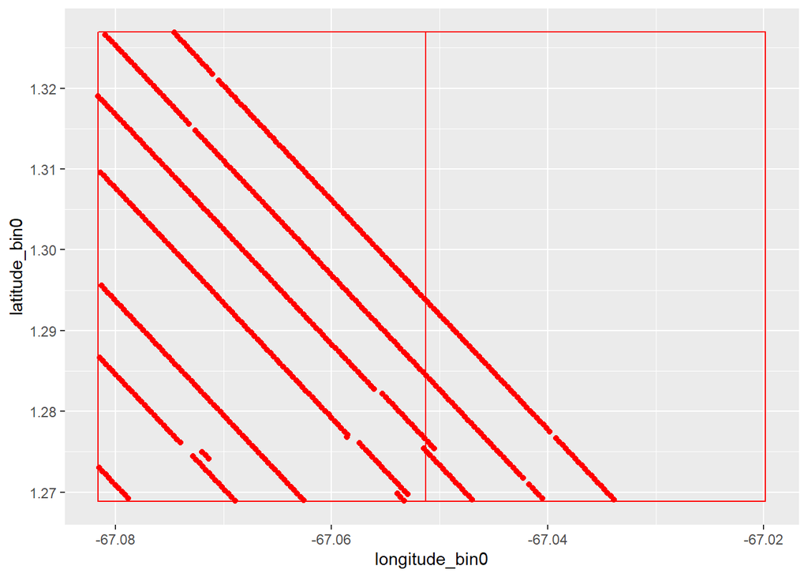

```r
level2BVPM_Geo_1_sp_clip= as.data.frame(level2BVPM_Geo_1_sp_clip)

ggplot() +
  geom_point(data = level2BVPM_Geo_1_sp_clip, aes(x=longitude_bin0, y = latitude_bin0), fill = NA, color = "red")+
  geom_polygon(data = STUDY_AREA, aes(x=long, y = lat, group = group), fill = NA, color = "red")
```

```r
class(level2BVPM_Geo_1_sp_clip)
```

```
## [1] "data.frame"
```

```r
write.csv(level2BVPM_Geo_1_sp_clip, "level2BVPM_Geo_1_sp_clip.csv", row.names = T)
```

## **3. SOME GEDI CALCULATIONS**

Let us go to open three GEDI files corresponding to the three GEDI levels (GEDI L1B, GEDI L2A, GEDI L2B)

```r
gedilevel1b<-readLevel1B(level1Bpath = paste0(outdir,"\\GEDI01_B_2019108080338_O01964_T05337_02_003_01_sub.h5"))
gedilevel2a<-readLevel2A(level2Apath = paste0(outdir,"\\GEDI02_A_2019108080338_O01964_T05337_02_001_01_sub.h5"))
gedilevel2b<-readLevel2B(level2Bpath = paste0(outdir,"\\GEDI02_B_2019108080338_O01964_T05337_02_001_01_sub.h5"))
```

We can build the GEDI full-waveform of a given pulse from GEDI Level1B data using the function getLevel1BWF.

```r
wf <- getLevel1BWF(gedilevel1b, shot_number="19640521100108408")
```

We also can build a plot for the GEDI full-waveform

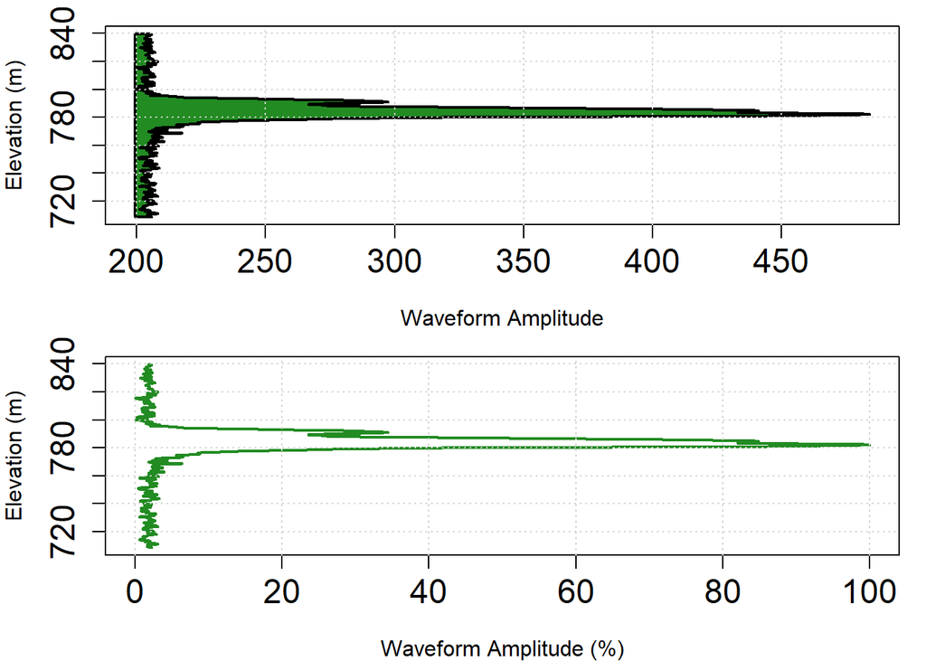

```r
par(mfrow = c(2,1), mar=c(4,4,1,1), cex.axis = 1.5)
plot(wf, relative=FALSE, polygon=TRUE, type="l", lwd=2, col="forestgreen",
     xlab="Waveform Amplitude", ylab="Elevation (m)")
grid()
plot(wf, relative=TRUE, polygon=FALSE, type="l", lwd=2, col="forestgreen",
     xlab="Waveform Amplitude (%)", ylab="Elevation (m)")
grid()
```

We also can get the Plant Area Index (PAI) and Plant Area Volume Density (PAVD) Profiles from the GEDI Level2B using the functions getLevel2BVPM getLevel2BPAIProfile and getLevel2BPAVDProfile.

```r
level2BVPM<-getLevel2BVPM(gedilevel2b)
head(level2BVPM[,c("beam","shot_number","pai","fhd_normal","omega","pgap_theta","cover")])
```

```
##        beam       shot_number         pai fhd_normal omega pgap_theta
## 1: BEAM0000 19640002800109382 0.007661204  0.6365142     1  0.9961758
## 2: BEAM0000 19640003000109383 0.086218357  2.2644432     1  0.9577964
## 3: BEAM0000 19640003200109384 0.299524575  1.8881851     1  0.8608801
## 4: BEAM0000 19640003400109385 0.079557180  1.6625489     1  0.9609926
## 5: BEAM0000 19640003600109386 0.018724868  1.5836401     1  0.9906789
## 6: BEAM0000 19640003800109387 0.017654873  1.2458609     1  0.9912092
##          cover
## 1: 0.003823273
## 2: 0.042192958
## 3: 0.139084846
## 4: 0.038997617
## 5: 0.009318732
## 6: 0.008788579
```

```r
level2BPAIProfile<-getLevel2BPAIProfile(gedilevel2b)
head(level2BPAIProfile[,c("beam","shot_number","pai_z0_5m","pai_z5_10m")])
```

```
##        beam       shot_number   pai_z0_5m   pai_z5_10m
## 1: BEAM0000 19640002800109382 0.007661204 0.0000000000
## 2: BEAM0000 19640003000109383 0.086218357 0.0581122264
## 3: BEAM0000 19640003200109384 0.299524575 0.0497199222
## 4: BEAM0000 19640003400109385 0.079557180 0.0004457365
## 5: BEAM0000 19640003600109386 0.018724868 0.0000000000
## 6: BEAM0000 19640003800109387 0.017654873 0.0000000000
```

```r
level2BPAVDProfile<-getLevel2BPAVDProfile(gedilevel2b)
head(level2BPAVDProfile[,c("beam","shot_number","pavd_z0_5m","pavd_z5_10m")])
```

```
##        beam       shot_number  pavd_z0_5m  pavd_z5_10m
## 1: BEAM0000 19640002800109382 0.001532241 0.0007661204
## 2: BEAM0000 19640003000109383 0.005621226 0.0086218351
## 3: BEAM0000 19640003200109384 0.049960934 0.0299524590
## 4: BEAM0000 19640003400109385 0.015822290 0.0079557188
## 5: BEAM0000 19640003600109386 0.003744974 0.0018724868
## 6: BEAM0000 19640003800109387 0.003530974 0.0017654872
```

Now we can plot Plant Area Index (PAI) and Plant Area Volume Density (PAVD) Profiles

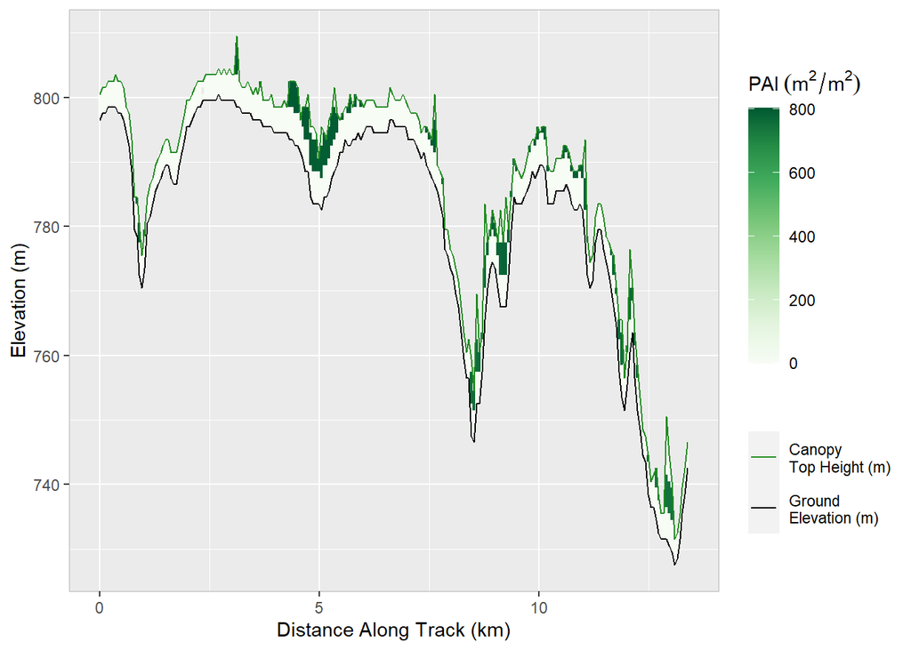

```r
#specify GEDI beam
beam="BEAM0101"

# Plot Level2B PAI Profile
gPAIprofile<-plotPAIProfile(level2BPAIProfile, beam=beam, elev=TRUE)
```

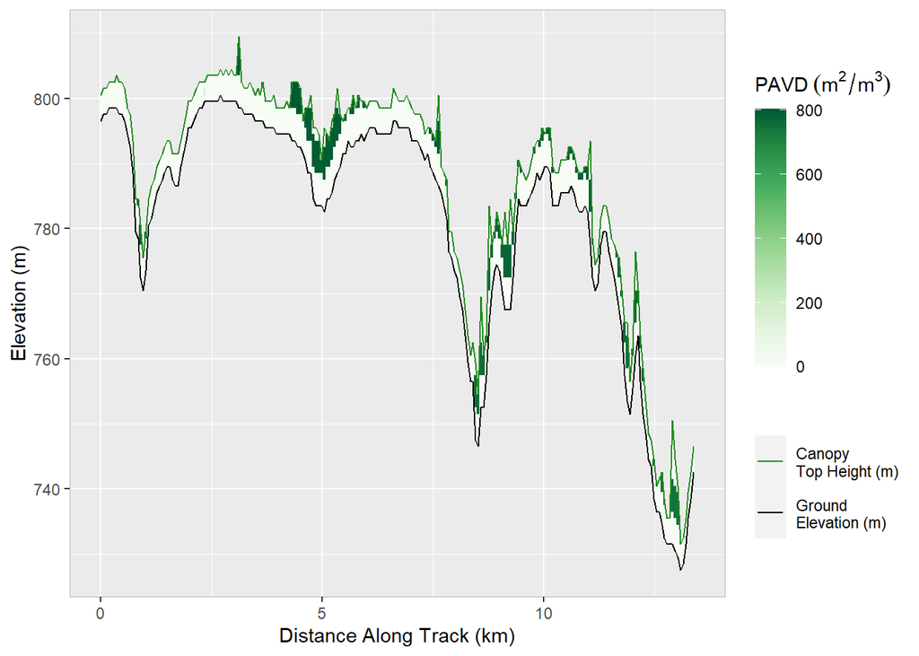

```r
# Plot Level2B PAVD Profile
gPAVDprofile<-plotPAVDProfile(level2BPAVDProfile, beam=beam, elev=TRUE)
```

## **CITED REFERENCES**

Carlos Alberto, S. 2021. rGEDI:NASA’s Global Ecosystem Dynamics Investigation (GEDI) Data Visualization and Processing. r- project.org.

Dubayah, R., J. B. Blair, S. Goetz, L. Fatoyinbo, M. Hansen, S. Healey, M. Hofton, G. Hurtt, J. Kellner, S. Luthcke, J. Armston, H. Tang, L. Duncanson, S. Hancock, P. Jantz, S. Marselis, P. L. Patterson, W. Qi, and C. Silva. 2020. The Global Ecosystem Dynamics Investigation: High-resolution laser ranging of the Earth’s forests and topography. Science of Remote Sensing 1:100002.

Potapov, P., X. Li, A. Hernandez-Serna, A. Tyukavina, M. C. Hansen, A. Kommareddy, A. Pickens, S. Turubanova, H. Tang, C. E. Silva, J. Armston, R. Dubayah, J. B. Blair, and M. Hofton. 2020. Mapping global forest canopy height through integration of GEDI and Landsat data. Remote Sensing of Environment:112165.